# Custom Curve and Start Functions

Zachery Moore

22 October 2026

# 1 Objective

`dosefitr` ships with a library of growth and dose-response models in `dosefitr_models`, but you aren’t limited to these. Any function of `x` can be used as a curve, and you can control how the fit is started either with a function that estimates starting values from the data or with fixed values.

This vignette uses the built-in `cars` dataset (stopping distance against speed) to show how to:

1. fit a built-in model,
2. inspect how a built-in model is defined,
3. supply your own curve function,
4. supply your own start function, and
5. supply fixed starting values instead.

# 2 Loading and visualising data

First, load the package.

```r
library(dosefitr)
```

`cars` records the speed of 50 cars and the distance each took to stop. Here we model speed as a function of stopping distance.

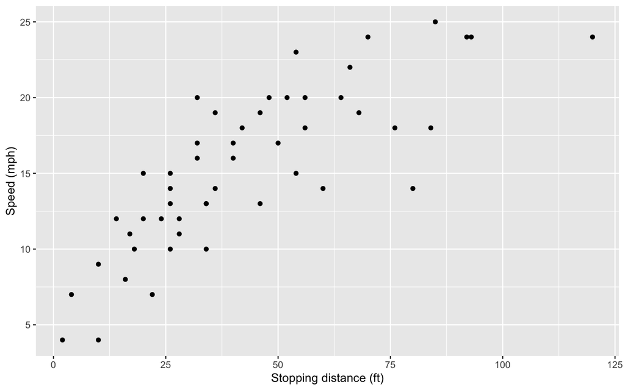

```r
ggplot2::ggplot(cars, ggplot2::aes(dist, speed)) +
  ggplot2::geom_point() +
  ggplot2::labs(x = "Stopping distance (ft)", y = "Speed (mph)")
```

Speed rises quickly at short distances and then levels off, which suggests a saturating curve.

# 3 Fitting a built-in model

Built-in models are selected by name through `curve_options$model`. Here we fit a four-parameter sigmoid.

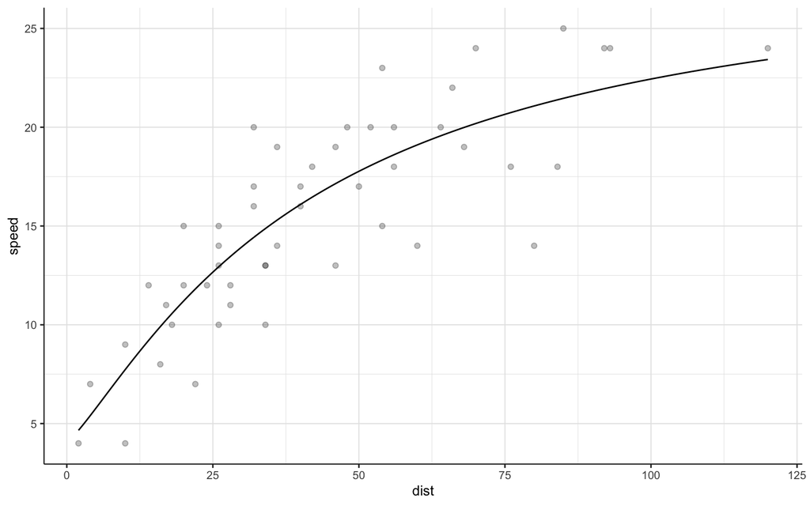

```r
cars_model <- fit_curve(
  cars,
  x_var = "dist",
  y_var = "speed",
  curve_options = list(model = "four_param_sigmoid")
)

plot_model(cars_model, x_var = "dist", y_var = "speed")
```

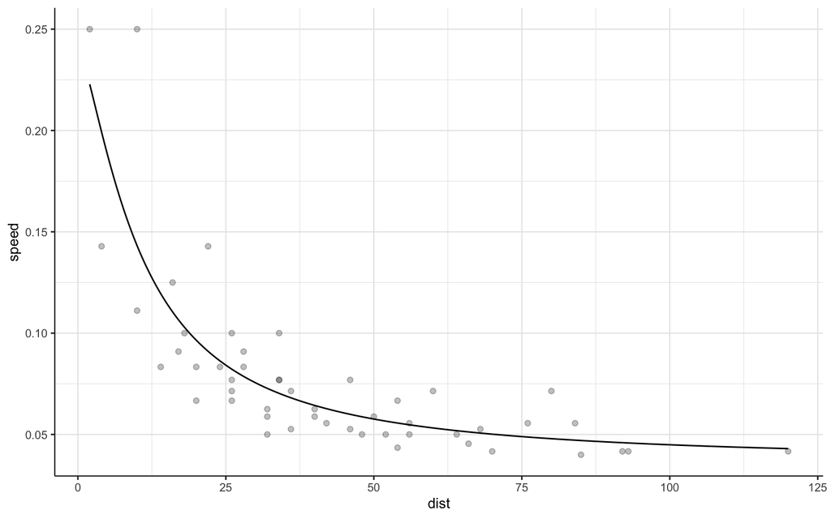

```r
cars_model_inverse <- fit_curve(
  cars |> dplyr::mutate(speed = 1 / speed),
  x_var = "dist",
  y_var = "speed",
  curve_options = list(model = "four_param_sigmoid")
)

plot_model(cars_model_inverse, x_var = "dist", y_var = "speed")
```

Comparing the parameter estimates for the two fits:

```r
cars_model$curve$nls_model
```

```
## Nonlinear regression model
##   model: y ~ f(x, top, bottom, ec50, slope)
##    data: data
## bottom    top   ec50  slope
##  4.075 28.737 41.705  1.224
##  residual sum-of-squares: 384.3
##
## Number of iterations to convergence: 5
## Achieved convergence tolerance: 1.49e-08
```

```r
cars_model_inverse$curve$nls_model
```

```
## Nonlinear regression model
##   model: y ~ f(x, top, bottom, ec50, slope)
##    data: data
##   bottom      top     ec50    slope
##  0.03615  0.24110 10.66200 -1.38855
##  residual sum-of-squares: 0.02684
##
## Number of iterations to convergence: 18
## Achieved convergence tolerance: 1.49e-08
```

# 4 How models are defined

Each entry in `dosefitr_models` is a list containing a curve function and the information needed to start the fit. Looking at one shows the structure a custom model needs to follow.

```r
names(dosefitr_models$four_param_sigmoid)
```

```
## [1] "curve_function" "start_function"
```

```r
dosefitr_models$four_param_sigmoid$curve_function
```

```
## function(x, top, bottom, ec50, slope) {
##             bottom + (top - bottom) / (1 + (ec50 / x)^slope)
##         }
```

A curve function takes `x` as its first argument, followed by one argument per model parameter, and returns the predicted `y`. The parameter names are what appear in the fitted model, and what a start function must return.

Related models can be compared the same way. For example, the log-scale version of the sigmoid, which expects `x` as log concentration:

```r
dosefitr_models$four_param_sigmoid_log$curve_function
```

```
## function(x, top, bottom, log_ec50, slope) {
##             bottom + (top - bottom) / (1 + 10^((log_ec50 - x) * slope))
##         }
```

# 5 Custom curve functions

To fit a model that isn’t in `dosefitr_models`, pass a function to `curve_options$curve_function`. A custom curve also needs starting values, which can come from a start function or be given directly.

## 5.1 A saturation curve

The levelling-off in `cars` looks like a simple saturation (hyperbolic) curve, with two parameters: `bmax`, the plateau, and `kd`, the `x` value at which half the plateau is reached.

```r
saturation_curve <- function(x, bmax, kd) {
  bmax * x / (kd + x)
}
```

A start function takes `x` and `y` and returns a named list of starting values, one per parameter. Both parameters here have a direct reading from the data: `bmax` is roughly the largest `y`, and `kd` is roughly the `x` where `y` is halfway between its minimum and maximum.

```r
saturation_start <- function(x, y) {
  mid <- min(y) + (max(y) - min(y)) / 2

  list(
    bmax = max(y),
    kd = x[which.min(abs(y - mid))]
  )
}

saturation_start(cars$dist, cars$speed)
```

```
## $bmax
## [1] 25
##
## $kd
## [1] 26
```

Pass both functions in `curve_options`:

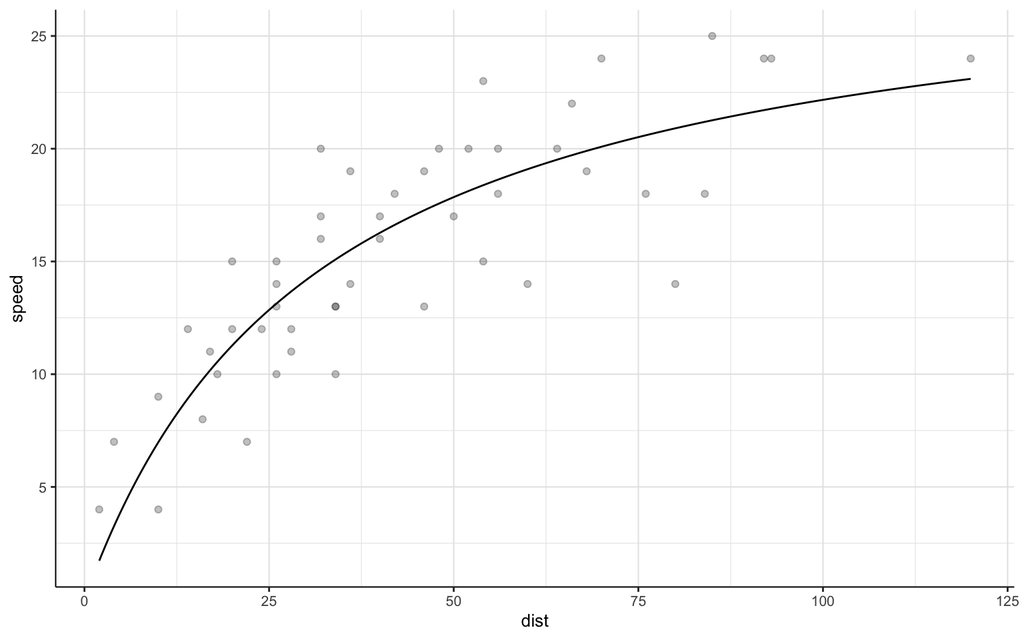

```r
cars_saturation <- fit_curve(
  cars,
  x_var = "dist",
  y_var = "speed",
  curve_options = list(
    curve_function = saturation_curve,
    start_function = saturation_start
  )
)

plot_model(cars_saturation, x_var = "dist", y_var = "speed")
```

```r
cars_saturation$curve$nls_model
```

```
## Nonlinear regression model
##   model: y ~ f(x, bmax, kd)
##    data: data
##  bmax    kd
## 29.23 31.88
##  residual sum-of-squares: 400
##
## Number of iterations to convergence: 4
## Achieved convergence tolerance: 1.49e-08
```

## 5.2 A quadratic curve

Any function of `x` works, including ones with no biological interpretation. Here we fit a quadratic.

```r
quad_curve <- function(x, a, b, c) {
  (a * x^2) + (b * x) + c
}
```

The parameters of a quadratic don’t map onto features you can read off a plot as easily. But because the model is linear in its parameters, an ordinary linear regression gives good starting values directly. This is a useful general trick: if a model can be written as a linear model, `lm()` makes a reliable start function.

```r
quad_start <- function(x, y) {
  coefs <- unname(stats::coef(stats::lm(y ~ I(x^2) + x)))

  list(
    a = coefs[2],
    b = coefs[3],
    c = coefs[1]
  )
}

quad_start(cars$dist, cars$speed)
```

```
## $a
## [1] -0.001528367
##
## $b
## [1] 0.3274544
##
## $c
## [1] 5.143961
```

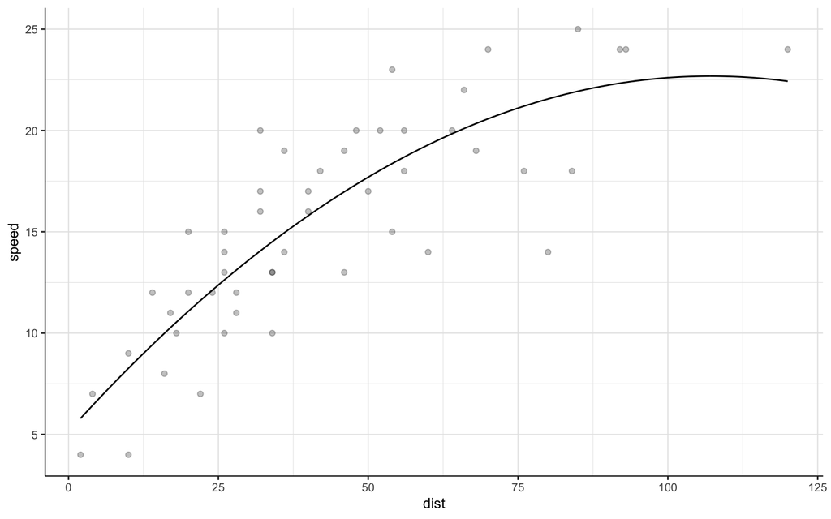

```r
cars_quadratic <- fit_curve(
  cars,
  x_var = "dist",
  y_var = "speed",
  curve_options = list(
    curve_function = quad_curve,
    start_function = quad_start
  )
)

plot_model(cars_quadratic, x_var = "dist", y_var = "speed")
```

# 6 Fixed starting values

If you already know roughly where the parameters should sit, or are fitting a single dataset, you can skip the start function and pass `start_values` directly as a named list.

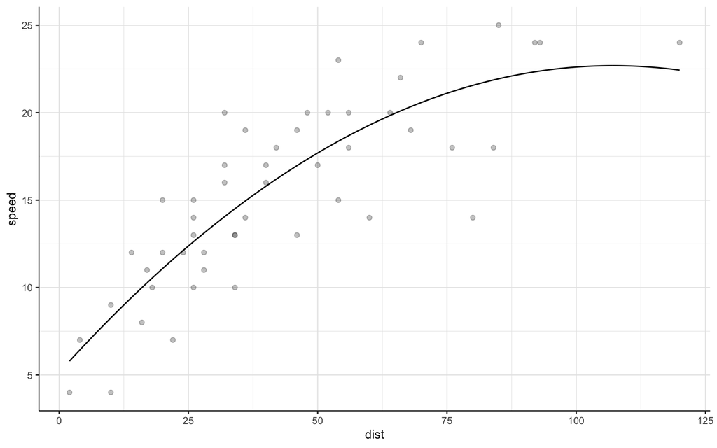

```r
cars_quadratic_start <- fit_curve(
  cars,
  x_var = "dist",
  y_var = "speed",
  curve_options = list(
    curve_function = quad_curve,
    start_values = list(a = -1, b = 1, c = 1)
  )
)

plot_model(cars_quadratic_start, x_var = "dist", y_var = "speed")
```

Both approaches converge to the same fit:

```r
cars_quadratic$curve$nls_model
```

```
## Nonlinear regression model
##   model: y ~ f(x, a, b, c)
##    data: data
##         a         b         c
## -0.001528  0.327454  5.143961
##  residual sum-of-squares: 397.1
##
## Number of iterations to convergence: 1
## Achieved convergence tolerance: 1.49e-08
```

```r
cars_quadratic_start$curve$nls_model
```

```
## Nonlinear regression model
##   model: y ~ f(x, a, b, c)
##    data: data
##         a         b         c
## -0.001528  0.327454  5.143961
##  residual sum-of-squares: 397.1
##
## Number of iterations to convergence: 2
## Achieved convergence tolerance: 1.49e-08
```

A start function is the better choice when fitting many datasets, such as one curve per concentration, since the starting values adapt to each one. Fixed values are simpler for a one-off fit, but may fail to converge if the data change scale.